# Multiple Imputation

Autor:in

Zugehörigkeit

Samuel Merk

Pädagogische Hochschule Karlsruhe

# 1 Überblick

Die multiple Imputation (MI) ist eine sehr mächtige Methode zum Umgang mit fehlenden Werten, die auf der Idee basiert, mehrere plausible Werte für die fehlenden Daten zu generieren. Diese Methode wurde von Rubin (1976) entwickelt und hat sich seitdem als eine der Standardmethoden für den Umgang mit fehlenden Daten etabliert. MI besteht aus drei Hauptschritten (siehe Abbildung 1):

1. **Imputation**: In diesem Schritt werden mehrere vollständige Datensätze generiert, indem fehlende Werte durch plausible Werte ersetzt werden. Dies geschieht in der Regel durch die Verwendung von Modellen, die auf den beobachteten Daten basieren, um die fehlenden Werte zu schätzen. Es können verschiedene Imputationsmodelle verwendet werden, z.B. lineare Regression, logistische Regression, ordinale Regression, predictive mean matching oder Random Forests.
2. **Analyse**: Jeder der generierten vollständigen Datensätze wird einzeln analysiert, z.B. durch die Schätzung von Regressionsmodellen, Effektstärken, Hypothesentests.
3. **Pooling**: Die Ergebnisse der Analysen der einzelnen Datensätze werden anschließend zusammengeführt, um eine einzige Schätzung und Inferenzstatistik zu erhalten. Hierzu werden spezielle Pooling-Methoden verwendet, die die Unsicherheit berücksichtigen, die durch die Imputation der fehlenden Werte entsteht.

[figure not shown]

Abbildung 1: Workflow des Missing Data Handling mit multipler Imputation

Im Umfeld des `{mice}`-Packages in R ist zu diesem Workflow auch die folgende Terminologie gebräuchlich geworden:

Terminologie im Umfeld von `{mice}` (siehe Buuren (2018))

| Klasse in `{mice}` | Häufiges Objekt Suffix | `{mice}`-Funktion | Beschreibung |
| --- | --- | --- | --- |
| mids | imp | mice() | Multipel imputierter Datensatz |
| mild | idl | complete() | Liste multipel imputierter Daten |
| mira | fit | with() | Wiederholte Analysen mit multipler Imputation |
| mipo | est | pool() | Pooling der Ergebnisse aus multipler Imputation |

# 2 Multiple Imputation in `{mice}`

Im oben beschriebenen Workflow ist die multiple Imputation besonders herausfordernd. Sie muss auf die diversen Arten (Skalenniveau, Kontinuität) und Verteilungen von Daten angepasst werden, die Missingness Patterns berücksichtigen und jeweils **alle** Prädiktoren der Missingness enthalten. Diese Schritte werden im folgenden Beispiel Schritt für Schritt bearbeitet

# 3 Ein artifizielles `{mice}`-Beispiel

## 3.1 Datengrundlage

```r
library(tidyverse)
N <- 1000

data_art <-
  tibble(
    x_comp = rnorm(N),
    y_comp = 2 + 0.5 * x_comp + rnorm(N),
    r_y = rbinom(N, 1, prob = plogis(.2 + 3 * x_comp)),
    r_x = rbinom(N, 1, prob = plogis(4 - 3 * y_comp)),
    y_beob = ifelse(r_y == 0, y_comp, NA),
    x_beob = x_comp
  )
```

## 3.2 Missingness Pattern

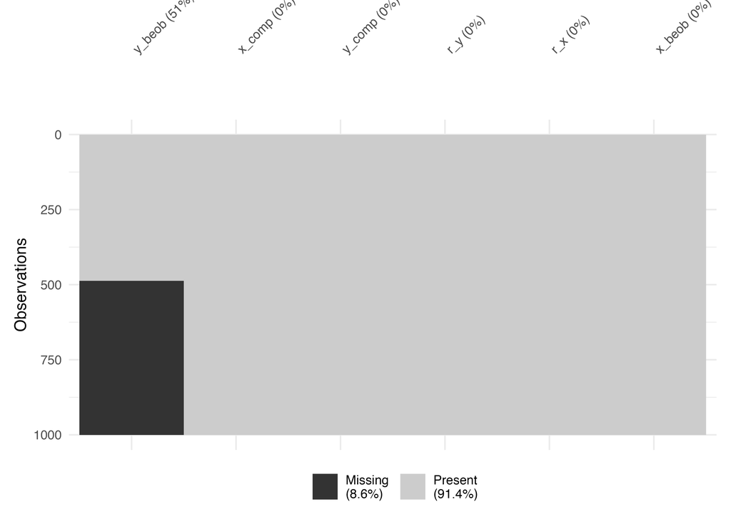

```r
library(naniar)
vis_miss(data_art, sort_miss = TRUE, cluster = TRUE) +
  theme(plot.margin = margin(t = 20, r = 10, b = 10, l = 10))
```

## 3.3 Missingness Mechanism

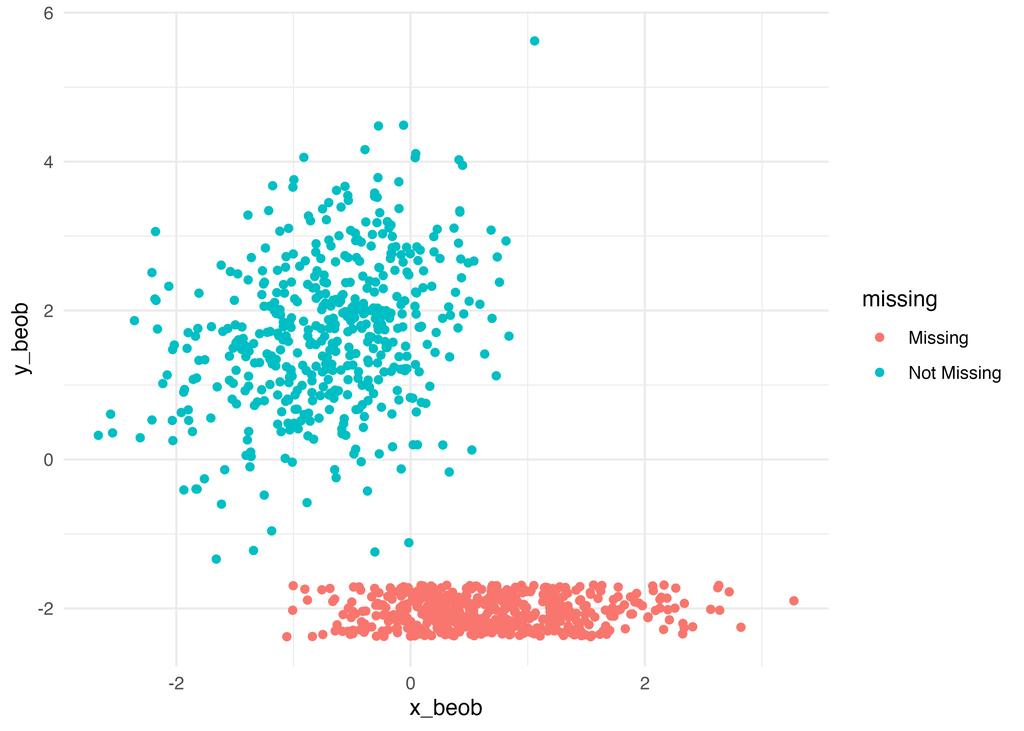

```r
ggplot(data_art, aes(x = x_beob, y = y_beob)) +
  geom_miss_point(jitter = 0.1) +
  theme_minimal()
```

## 3.4 Imputation

```r
library(mice)
data_art_imp <- mice(
  data_art %>% select(x_beob, y_beob),
  m = 5,
  seed = 1895
)
summary(data_art_imp)
```

```
Class: mids
Number of multiple imputations:  5
Imputation methods:
x_beob y_beob
    ""  "pmm"
PredictorMatrix:
       x_beob y_beob
x_beob      0      1
y_beob      1      0
```

## 3.5 Visual Check des Imputationsalgorithmus

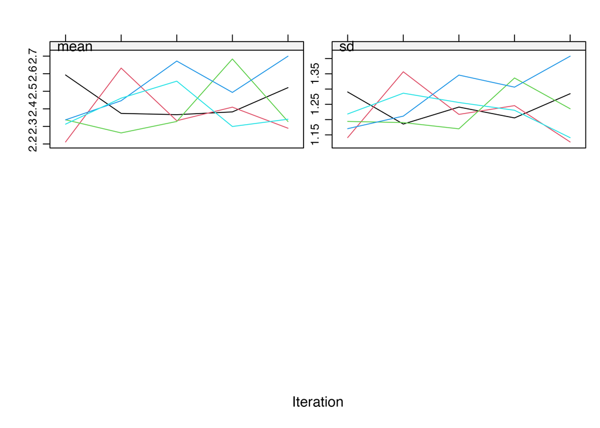

```r
plot(data_art_imp)
```

## 3.6 Visual Check der Imputation

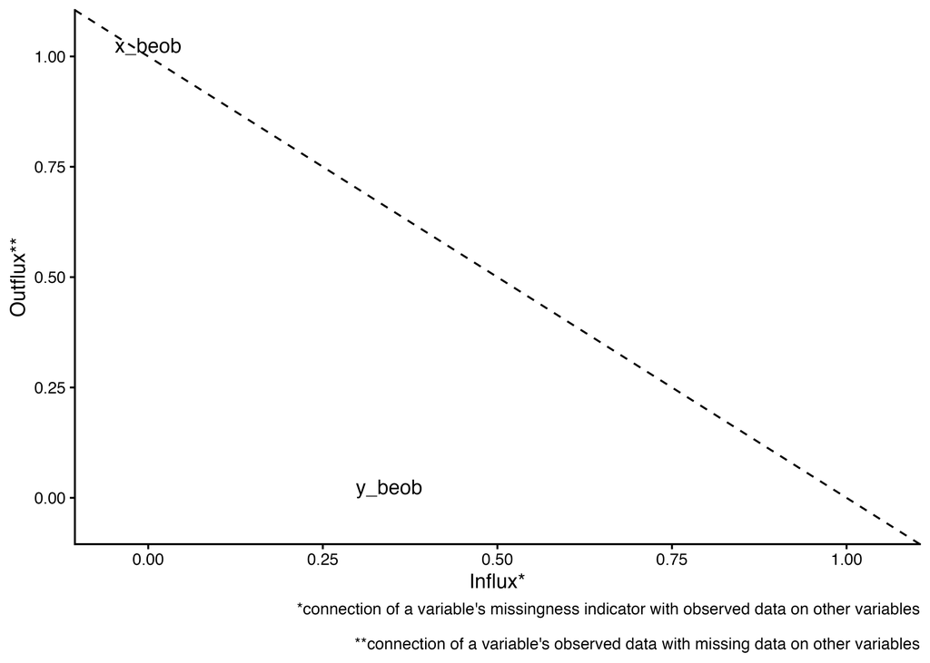

```r
library(ggmice)
plot_flux(data_art %>% select(x_beob, y_beob))
```

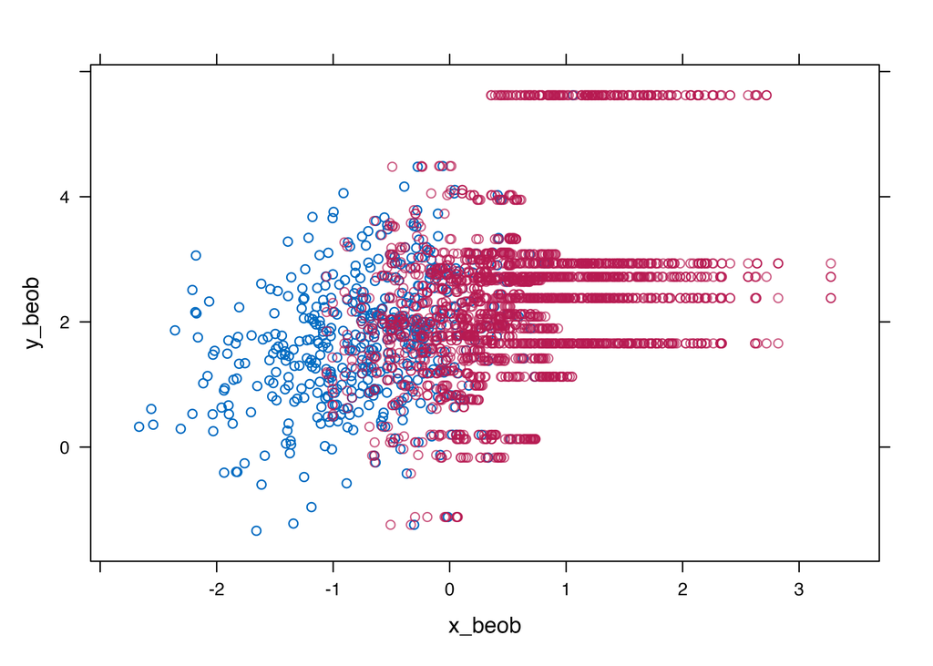

```r
mice::xyplot(data_art_imp, y_beob ~ x_beob)
```

## 3.7 Vergleich Regressionsanalytischer Ergebnisse

### 3.7.1 Gepoolte Imputierte Regression

```r
reg_fit <- with(data_art_imp, lm(scale(y_beob) ~ scale(x_beob)))
summary(reg_fit)
```

```
# A tibble: 10 × 7
   term          estimate std.error statistic   p.value  nobs df.residual
   <chr>            <dbl>     <dbl>     <dbl>     <dbl> <int>       <dbl>
 1 (Intercept)   2.33e-15    0.0283  8.24e-14 1.000e+ 0  1000         998
 2 scale(x_beob) 4.47e- 1    0.0283  1.58e+ 1 2.10 e-50  1000         998
 3 (Intercept)   2.75e-15    0.0289  9.50e-14 1.000e+ 0  1000         998
 4 scale(x_beob) 4.05e- 1    0.0289  1.40e+ 1 1.11 e-40  1000         998
 5 (Intercept)   4.33e-15    0.0283  1.53e-13 1.000e+ 0  1000         998
 6 scale(x_beob) 4.48e- 1    0.0283  1.58e+ 1 1.45 e-50  1000         998
 7 (Intercept)   2.19e-15    0.0280  7.83e-14 1.000e+ 0  1000         998
 8 scale(x_beob) 4.65e- 1    0.0280  1.66e+ 1 6.86 e-55  1000         998
 9 (Intercept)   3.98e-15    0.0289  1.38e-13 1.000e+ 0  1000         998
10 scale(x_beob) 4.10e- 1    0.0289  1.42e+ 1 7.38 e-42  1000         998
```

```r
reg_fit
```

```
call :
with.mids(data = data_art_imp, expr = lm(scale(y_beob) ~ scale(x_beob)))

call1 :
mice(data = data_art %>% select(x_beob, y_beob), m = 5, seed = 1895)

nmis :
[1]   0 513

analyses :
[[1]]

Call:
lm(formula = scale(y_beob) ~ scale(x_beob))

Coefficients:
  (Intercept)  scale(x_beob)
    2.332e-15      4.475e-01


[[2]]

Call:
lm(formula = scale(y_beob) ~ scale(x_beob))

Coefficients:
  (Intercept)  scale(x_beob)
    2.748e-15      4.046e-01


[[3]]

Call:
lm(formula = scale(y_beob) ~ scale(x_beob))

Coefficients:
  (Intercept)  scale(x_beob)
    4.325e-15      4.482e-01


[[4]]

Call:
lm(formula = scale(y_beob) ~ scale(x_beob))

Coefficients:
  (Intercept)  scale(x_beob)
    2.192e-15      4.654e-01


[[5]]

Call:
lm(formula = scale(y_beob) ~ scale(x_beob))

Coefficients:
  (Intercept)  scale(x_beob)
    3.976e-15      4.102e-01
```

```r
reg_est <- pool(reg_fit)
summary(reg_est)
```

```
           term     estimate  std.error    statistic        df      p.value
1   (Intercept) 3.114749e-15 0.02847602 1.093815e-13 996.00599 1.000000e+00
2 scale(x_beob) 4.351664e-01 0.04061074 1.071555e+01  15.03445 1.952724e-08
```

```r
reg_est
```

```
Class: mipo    m = 5
           term m     estimate         ubar            b            t dfcom
1   (Intercept) 5 3.114749e-15 0.0008108835 9.517112e-31 0.0008108835   998
2 scale(x_beob) 5 4.351664e-01 0.0008116952 6.979472e-04 0.0016492318   998
         df          riv       lambda        fmi
1 996.00599 1.408406e-27 1.408406e-27 0.00200199
2  15.03445 1.031836e+00 5.078344e-01 0.56241501
```

### 3.7.2 Listwise Deletion und vollständige Daten

```r
reg_listwise <- lm(y_beob ~ x_beob, data = data_art)
reg_comp <- lm(y_comp ~ x_comp, data = data_art)
sjPlot::tab_model(reg_listwise, reg_comp, show.std = T, show.ci = F)
```

|  | y beob |  |  | y comp |  |  |
| --- | --- | --- | --- | --- | --- | --- |
| Predictors | Estimates | std. Beta | p | Estimates | std. Beta | p |
| (Intercept) | 2.03 | -0.00 | **<0.001** | 2.02 | -0.00 | **<0.001** |
| x beob | 0.48 | 0.31 | **<0.001** |  |  |  |
| x comp |  |  |  | 0.51 | 0.47 | **<0.001** |
| Observations | 487 |  |  | 1000 |  |  |
| R<sup>2</sup> / R<sup>2</sup> adjusted | 0.093 / 0.092 |  |  | 0.220 / 0.219 |  |  |

# 4 Ein »Real World« `{mice}`-Beispiel

## 4.1 Datengrundlage

Als Datengrundlage verwenden wir einen Ausschnitt des STAR-Experiments, indem die experimentell die Wirkung einer Klassengrößenreduktion auf die Schulleistung untersucht wurde (Word, 1990). Um zunächst das Problem genesteter Daten zu umgehen, verwenden wir nur die Daten je einer Schüler:in pro Klasse. Die Daten enthalten die folgenden Variablen:

```r
library(haven)
library(dplyr)
library(codebook)

set.seed(1895)
data_star <- read_sav(
  "https://raw.githubusercontent.com/sammerk/GRAPH-Missing-Data/master/data_missing_workshop.sav"
) %>%
    group_by(g3tchid) %>%
    sample_n(1) %>%
    ungroup()

label_browser_static(data_star)
```

| name | label | value_labels |
| --- | --- | --- |
| g3tchid | GRADE 3 TEACHER ID |  |
| g3tmathss | TOTAL MATH SCALE SCORE SAT GRADE 3 |  |
| g3treadss | TOTAL READING SCALE SCORE SAT GRADE 3 |  |
| g3freelunch | FREE/REDUCED LUNCH STATUS GRADE 3 | 1. FREE LUNCH,2. NON-FREE LUNCH |
| g3classsize | CLASS SIZE GRADE 3 |  |
| g3classtype | CLASSROOM TYPE GRADE 3 | 1. SMALL CLASS,2. REGULAR CLASS,3. REGULAR + AIDE CLASS |
| g4ptimpt | GRADE 4 PARTICIPATION: THINKS SCHOOL IS IMPORTANT | 1. NEVER,3. SOMETIMES,5. ALWAYS |
| g4ptcrit | GRADE 4 PARTICIPATION: IS CRITICAL OF ACHIEVERS | 1. NEVER,3. SOMETIMES,5. ALWAYS |
| g4ptcrts | GRADE 4 PARTICIPATION: CRITICIZES SUBJECT MATTER | 1. NEVER,3. SOMETIMES,5. ALWAYS |
| classID | GRADE 3 TEACHER ID |  |

> Forschungsfragen: Wie wirkt sich die Klassengröße auf die Lese-, Mathematikleistung und Partizipation aus? Gibt differentielle Effekte nach SES?

## 4.2 Missingness Patters

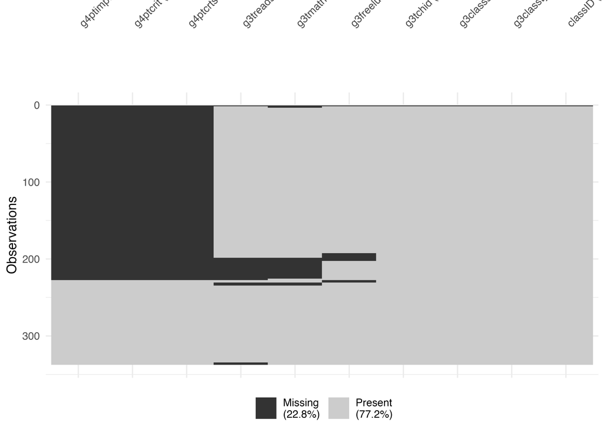

```r
library(naniar)
vis_miss(data_star, sort_miss = TRUE, cluster = TRUE)
```

## 4.3 (Co-)Variation und Verteilung der Daten

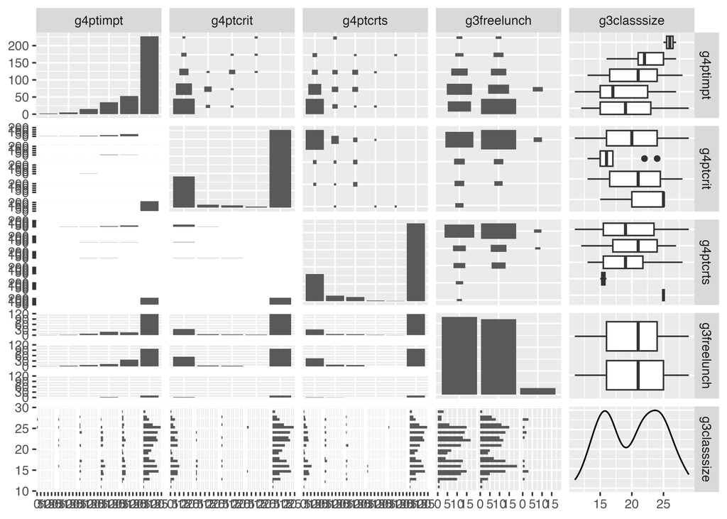

```r
library(GGally)
ggpairs(
  data_star %>%
    select(starts_with("g4"), g3freelunch, g3classsize) %>%
    mutate(across(c(starts_with("g4pt"), g3freelunch), as.factor))
)
```

## 4.4 Missing Mechanisms

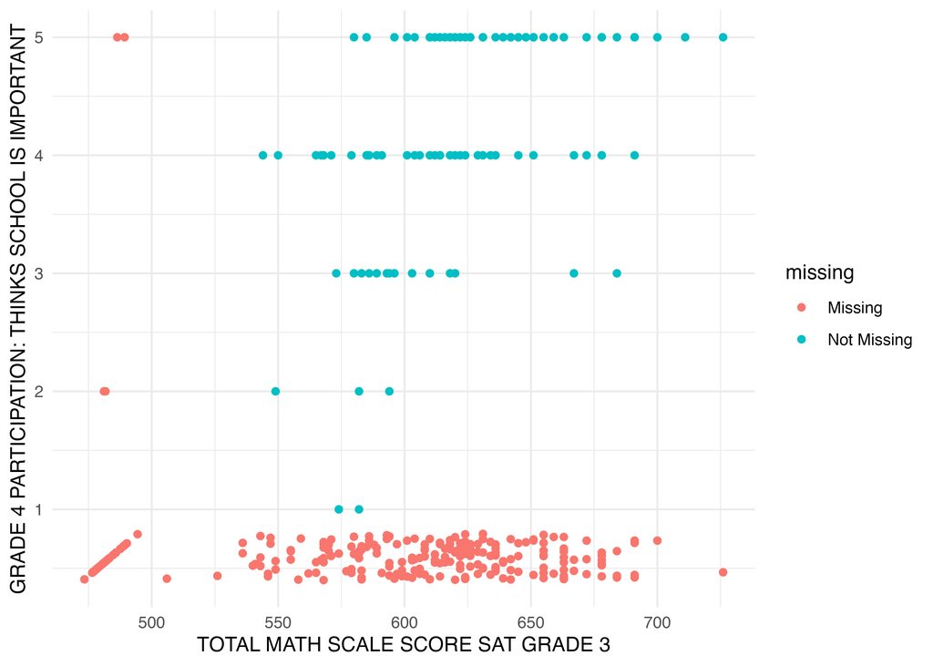

```r
library(ggplot2)
library(ggmice)
ggplot(data_star, aes(x = g3tmathss, y = g4ptimpt)) +
  geom_miss_point(jitter = 0.1) +
  theme_minimal()
```

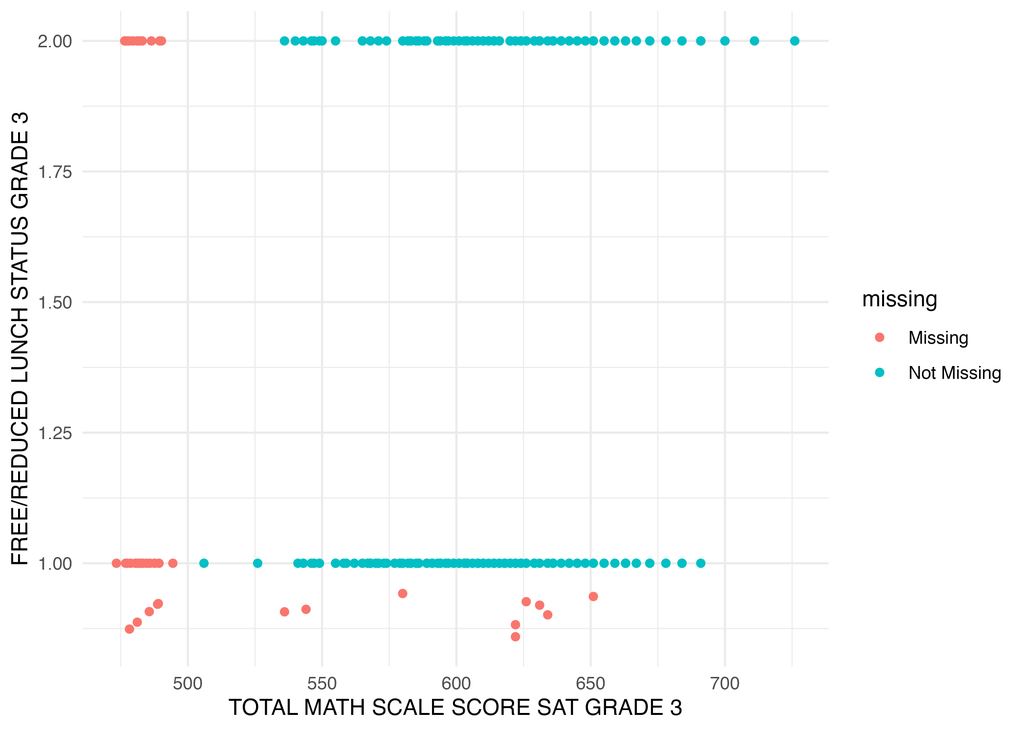

```r
ggplot(data_star, aes(x = g3tmathss, y = g3freelunch)) +
  geom_miss_point(jitter = 0.1) +
  theme_minimal()
```

```r
mcar_test(data_star %>% select(g4ptimpt, g3tmathss, g3freelunch, g3classsize))
```

```
# A tibble: 1 × 4
  statistic    df p.value missing.patterns
      <dbl> <dbl>   <dbl>            <int>
1      23.9    14  0.0471                8
```

## 4.5 Imputation

```r
library(mice)
data_star_unlabeled <- data_star %>%
    sjlabelled::remove_all_labels() %>%
    as_tibble() %>%
    mutate(across(c(g3classtype, g3freelunch), as.factor))

data_star_imp <- mice(
  data_star_unlabeled %>% select(-g3tchid, -classID),
  m = 5,
  seed = 1895
)
summary(data_star_imp)
```

```
Class: mids
Number of multiple imputations:  5
Imputation methods:
  g3tmathss   g3treadss g3freelunch g3classsize g3classtype    g4ptimpt
      "pmm"       "pmm"    "logreg"       "pmm"   "polyreg"       "pmm"
   g4ptcrit    g4ptcrts
      "pmm"       "pmm"
PredictorMatrix:
            g3tmathss g3treadss g3freelunch g3classsize g3classtype g4ptimpt
g3tmathss           0         1           1           1           1        1
g3treadss           1         0           1           1           1        1
g3freelunch         1         1           0           1           1        1
g3classsize         1         1           1           0           1        1
g3classtype         1         1           1           1           0        1
g4ptimpt            1         1           1           1           1        0
            g4ptcrit g4ptcrts
g3tmathss          1        1
g3treadss          1        1
g3freelunch        1        1
g3classsize        1        1
g3classtype        1        1
g4ptimpt           1        1
```

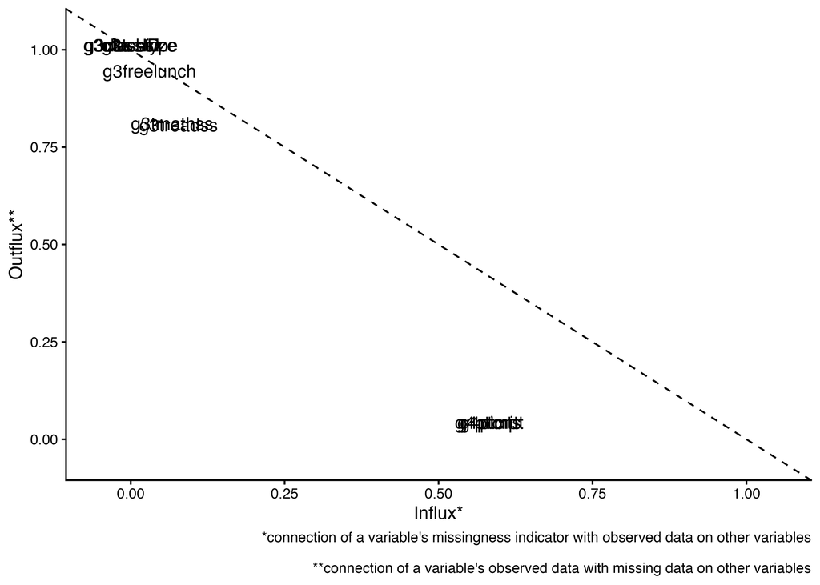

```r
plot_flux(data_star_unlabeled)
```

## 4.6 Analyse

```r
reg_fit <- with(data_star_imp, lm(scale(g4ptimpt) ~ scale(g3tmathss) + g3freelunch + scale(g3classsize)))
summary(reg_fit)
```

```
# A tibble: 20 × 7
   term               estimate std.error statistic  p.value  nobs df.residual
   <chr>                 <dbl>     <dbl>     <dbl>    <dbl> <int>       <dbl>
 1 (Intercept)         -0.0644    0.0683    -0.943 3.47e- 1   337         333
 2 scale(g3tmathss)     0.466     0.0497     9.36  1.24e-18   337         333
 3 g3freelunch2         0.131     0.0996     1.31  1.90e- 1   337         333
 4 scale(g3classsize)  -0.0534    0.0481    -1.11  2.68e- 1   337         333
 5 (Intercept)          0.122     0.0703     1.74  8.28e- 2   337         333
 6 scale(g3tmathss)     0.449     0.0512     8.76  9.74e-17   337         333
 7 g3freelunch2        -0.248     0.102     -2.44  1.54e- 2   337         333
 8 scale(g3classsize)  -0.0173    0.0497    -0.349 7.27e- 1   337         333
 9 (Intercept)         -0.0687    0.0742    -0.926 3.55e- 1   337         333
10 scale(g3tmathss)     0.304     0.0539     5.64  3.63e- 8   337         333
11 g3freelunch2         0.139     0.108      1.29  1.99e- 1   337         333
12 scale(g3classsize)  -0.0585    0.0522    -1.12  2.63e- 1   337         333
13 (Intercept)         -0.133     0.0668    -1.99  4.71e- 2   337         333
14 scale(g3tmathss)     0.454     0.0486     9.36  1.27e-18   337         333
15 g3freelunch2         0.272     0.0974     2.79  5.54e- 3   337         333
16 scale(g3classsize)  -0.102     0.0474    -2.15  3.22e- 2   337         333
17 (Intercept)         -0.113     0.0659    -1.71  8.80e- 2   337         333
18 scale(g3tmathss)     0.491     0.0479    10.2   1.41e-21   337         333
19 g3freelunch2         0.229     0.0961     2.38  1.77e- 2   337         333
20 scale(g3classsize)  -0.0995    0.0463    -2.15  3.22e- 2   337         333
```

```r
reg_est <- pool(reg_fit)
summary(reg_est)
```

```
                term    estimate  std.error  statistic        df     p.value
1        (Intercept) -0.05133345 0.13083998 -0.3923376  7.113558 0.706299218
2   scale(g3tmathss)  0.43269370 0.09527636  4.5414592  7.099200 0.002569633
3       g3freelunch2  0.10437369 0.24719258  0.4222363  5.201748 0.689739014
4 scale(g3classsize) -0.06611781 0.06225896 -1.0619807 23.677596 0.298956806
```

```r
reg_est
```

```
Class: mipo    m = 5
                term m    estimate        ubar           b           t dfcom
1        (Intercept) 5 -0.05133345 0.004785302 0.010278166 0.017119102   333
2   scale(g3tmathss) 5  0.43269370 0.002530992 0.005455494 0.009077585   333
3       g3freelunch2 5  0.10437369 0.010125276 0.042482412 0.061104170   333
4 scale(g3classsize) 5 -0.06611781 0.002378723 0.001247879 0.003876178   333
         df       riv    lambda       fmi
1  7.113558 2.5774337 0.7204700 0.7757483
2  7.099200 2.5865721 0.7211822 0.7763980
3  5.201748 5.0348154 0.8342948 0.8747021
4 23.677596 0.6295203 0.3863225 0.4323294
```

## Literatur

Buuren, S. van. (2018). *Flexible imputation of missing data* (2. Aufl.). Boca Raton: CRC. Abgerufen von https://stefvanbuuren.name/fimd/

Rubin, D. B. (1976). [Inference and missing data](https://doi.org/10.1093/biomet/63.3.581). *Biometrika*, *63*(3), 581–592.

Word, E. R. (1990). *The state of Tennessee’s student/teacher achievement ratio (STAR) project: Technical report (1985-1990).* (S. 398).